# Estudio de Bebés Recién Nacidos

Sebastian Landeo

2024-08-02

## Pregunta 1

Utiliza str() y head() para explorar la estructura, y con help(), mirar el significado de cada variable.

**low**

indicador de peso al nacer inferior a 2,5 kg.

**age**

edad de la madre en años.

**lwt**

peso de la madre en libras en el último período menstrual.

**race**

raza de la madre (1 = blanca, 2 = negra, 3 = otra).

**smoke**

estado de tabaquismo durante el embarazo.

**ptl**

número de partos prematuros previos.

**ht**

antecedentes de hipertensión.

**ui**

presencia de irritabilidad uterina.

**ftv**

número de visitas al médico durante el primer trimestre.

**bwt**

peso al nacer en gramos.

```r
library(MASS)
copia = birthwt
str(copia)
```

```
## 'data.frame':    189 obs. of  10 variables:
##  $ low  : int  0 0 0 0 0 0 0 0 0 0 ...
##  $ age  : int  19 33 20 21 18 21 22 17 29 26 ...
##  $ lwt  : int  182 155 105 108 107 124 118 103 123 113 ...
##  $ race : int  2 3 1 1 1 3 1 3 1 1 ...
##  $ smoke: int  0 0 1 1 1 0 0 0 1 1 ...
##  $ ptl  : int  0 0 0 0 0 0 0 0 0 0 ...
##  $ ht   : int  0 0 0 0 0 0 0 0 0 0 ...
##  $ ui   : int  1 0 0 1 1 0 0 0 0 0 ...
##  $ ftv  : int  0 3 1 2 0 0 1 1 1 0 ...
##  $ bwt  : int  2523 2551 2557 2594 2600 2622 2637 2637 2663 2665 ...
```

```r
head(copia)
```

```
##    low age lwt race smoke ptl ht ui ftv  bwt
## 85   0  19 182    2     0   0  0  1   0 2523
## 86   0  33 155    3     0   0  0  0   3 2551
## 87   0  20 105    1     1   0  0  0   1 2557
## 88   0  21 108    1     1   0  0  1   2 2594
## 89   0  18 107    1     1   0  0  1   0 2600
## 91   0  21 124    3     0   0  0  0   0 2622
```

```r
help("birthwt")
```

```
## starting httpd help server ... done
```

## Pregunta 2

Calcula una tabla de frecuencias relativas marginales de los pares raza de la madre y peso inferior a 2.5 kg o no, que permita ver si la raza de la madre influye en el peso del bebé.

```r
tablita = table(copia$race,copia$low)
dimnames(tablita) =list(Raza = c("Blanca", "Negra", "Otra"), Peso = c("Mayor a 2.5kg", "Menor a 2.5kg"))
tablita
```

```
##         Peso
## Raza     Mayor a 2.5kg Menor a 2.5kg
##   Blanca            73            23
##   Negra             15            11
##   Otra              42            25
```

```r
prop.table(tablita, margin = 1)
```

```
##         Peso
## Raza     Mayor a 2.5kg Menor a 2.5kg
##   Blanca     0.7604167     0.2395833
##   Negra      0.5769231     0.4230769
##   Otra       0.6268657     0.3731343
```

## Pregunta 3

Dibuja un diagrama de mosaico de la tabla del ejercicio anterior.

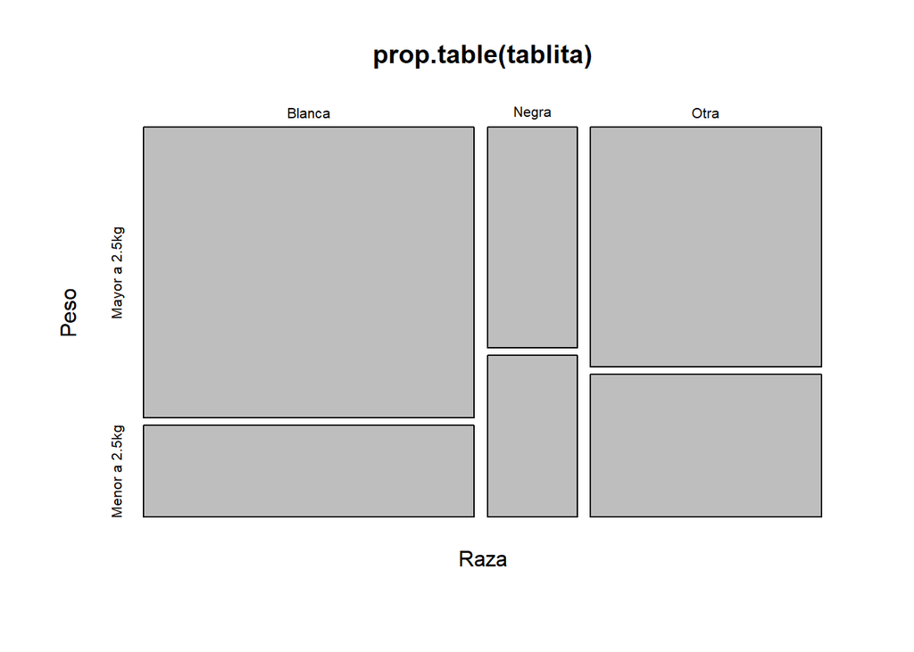

```r
#Primera variable en el eje x, la segunda en el eje y
plot(prop.table(tablita))
```

```r
# Da lo mismo
# plot(prop.table(tablita), margin = 1)
# plot(prop.table(tablita), margin = 2)
```

## Pregunta 4

Dibuja un diagrama bidimensional de barras, con las barras organizadas en bloques, que permita visualizar la información de los ejercicios anteriores. Aprovecha para poner nombres adecuados a los bloques, colores a las barras y añadir una leyenda que explique qué representa cada barra.

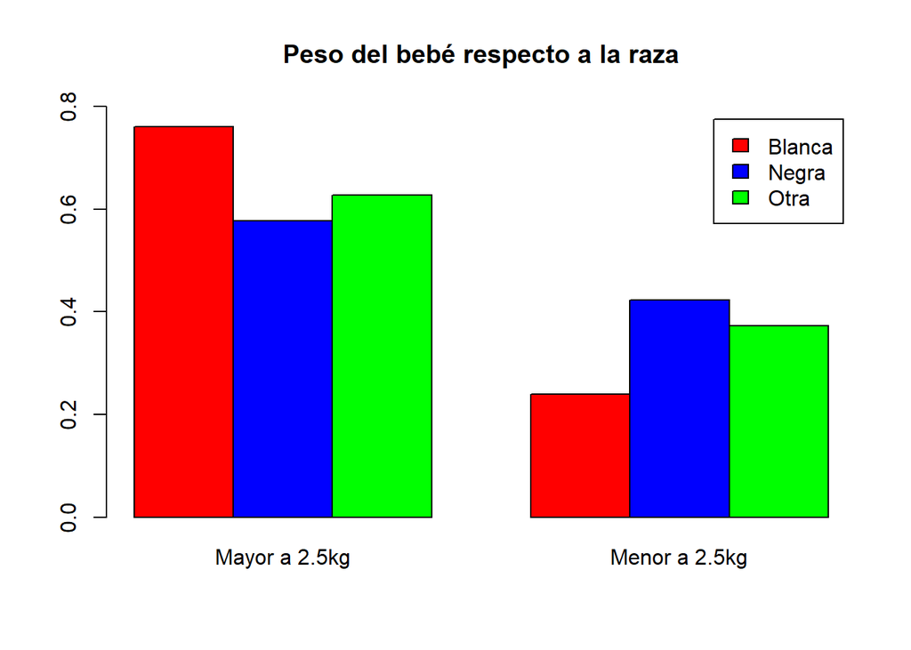

```r
barplot(prop.table(tablita, margin = 1), main = "Peso del bebé respecto a la raza",
        beside = TRUE,
        legend.text = TRUE,
        col = c("red","blue","green"),
        ylim = c(0,0.8))
```

```r
#Si pones margin 2, harías un frecuencia relativa marginal respecto al peso, y no a la raza que es lo que te piden
#La división o proporcion o frecuencia relativa, nos permite que los datos entre si no sean tan equidistantes
```

## Pregunta 5

```r
fumadorxpeso = table(copia$smoke,copia$low)
dimnames(fumadorxpeso) =list(Fumadora = c("No", "Sí"), Peso = c("Mayor a 2.5kg", "Menor a 2.5kg"))
fumadorxpeso
```

```
##         Peso
## Fumadora Mayor a 2.5kg Menor a 2.5kg
##       No            86            29
##       Sí            44            30
```

```r
prop.table(fumadorxpeso, margin = 1)
```

```
##         Peso
## Fumadora Mayor a 2.5kg Menor a 2.5kg
##       No     0.7478261     0.2521739
##       Sí     0.5945946     0.4054054
```

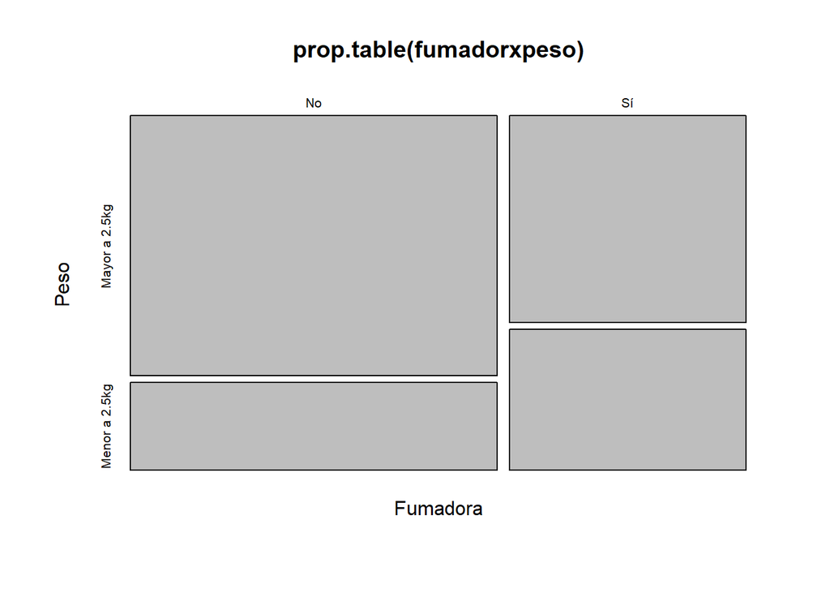

```r
plot(prop.table(fumadorxpeso))
```

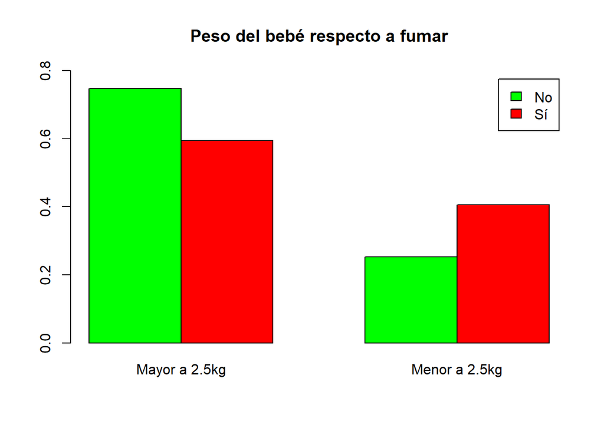

```r
barplot(prop.table(fumadorxpeso, margin = 1), main = "Peso del bebé respecto a fumar",
        beside = TRUE,
        legend.text = TRUE,
        col = c("green","red"),
        ylim = c(0,0.8))
```

**Conclusión**

De la mayoría de los que tienen un peso menor a 2.5 kg, son fumadores

```r
hipertencionxpeso = table(copia$ht,copia$low)
dimnames(hipertencionxpeso) =list(Hipertensión = c("No", "Sí"), Peso = c("Mayor a 2.5kg", "Menor a 2.5kg"))
hipertencionxpeso
```

```
##             Peso
## Hipertensión Mayor a 2.5kg Menor a 2.5kg
##           No           125            52
##           Sí             5             7
```

```r
prop.table(hipertencionxpeso, margin = 1)
```

```
##             Peso
## Hipertensión Mayor a 2.5kg Menor a 2.5kg
##           No     0.7062147     0.2937853
##           Sí     0.4166667     0.5833333
```

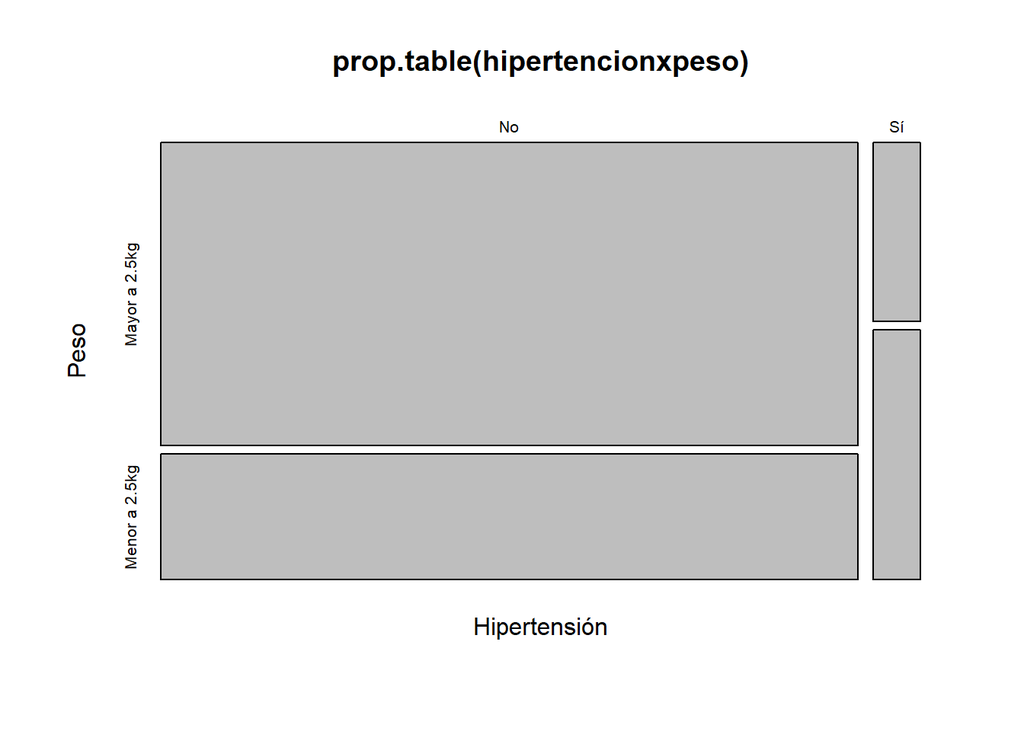

```r
plot(prop.table(hipertencionxpeso))
```

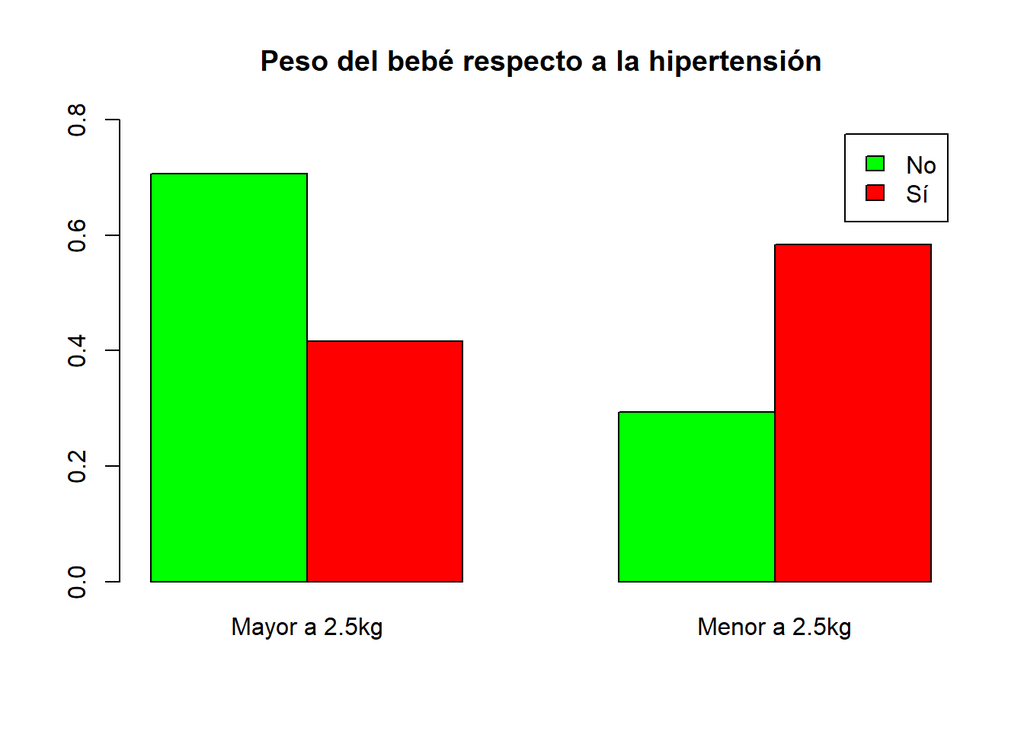

```r
barplot(prop.table(hipertencionxpeso, margin = 1), main = "Peso del bebé respecto a la hipertensión",
        beside = TRUE,
        legend.text = TRUE,
        col = c("green","red"),
        ylim = c(0,0.8))
```

**Conclusión**

## Pregunta 7

Calcula una tabla de frecuencias relativas marginales de la terna raza de la madre, madre fumadora o no y peso inferior a 2.5 kg o no, que permita ver si la raza de la madre y su condición de fumadora o no fumadora influyen en el peso del bebé.

```r
rfxpeso = table(copia$race, copia$smoke, copia$low)
dimnames(rfxpeso) =list(Raza = c("Blanca", "Negra", "Otra"),
                        Fuma = c("No", "Sí"),
                        Peso = c("Mayor a 2.5kg", "Menor a 2.5kg"))
rfxpeso
```

```
## , , Peso = Mayor a 2.5kg
##
##         Fuma
## Raza     No Sí
##   Blanca 40 33
##   Negra  11  4
##   Otra   35  7
##
## , , Peso = Menor a 2.5kg
##
##         Fuma
## Raza     No Sí
##   Blanca  4 19
##   Negra   5  6
##   Otra   20  5
```

```r
ftable(rfxpeso)
```

```
##             Peso Mayor a 2.5kg Menor a 2.5kg
## Raza   Fuma
## Blanca No                   40             4
##        Sí                   33            19
## Negra  No                   11             5
##        Sí                    4             6
## Otra   No                   35            20
##        Sí                    7             5
```

```r
prop.table(rfxpeso, margin = c(1,2))
```

```
## , , Peso = Mayor a 2.5kg
##
##         Fuma
## Raza             No         Sí
##   Blanca 0.90909091 0.63461538
##   Negra  0.68750000 0.40000000
##   Otra   0.63636364 0.58333333
##
## , , Peso = Menor a 2.5kg
##
##         Fuma
## Raza             No         Sí
##   Blanca 0.09090909 0.36538462
##   Negra  0.31250000 0.60000000
##   Otra   0.36363636 0.41666667
```

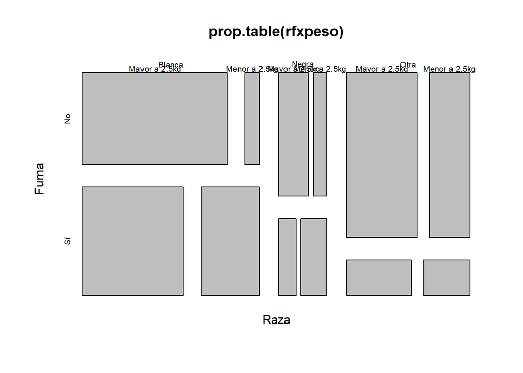

```r
plot(prop.table(rfxpeso))
```

```r
# Ejemplo dentro de las personas blancas y que no fuman, el 0.9 de ellos tiene un peso mayor a 2.5
```

# Pregunta 8

Dibuja un diagrama de mosaico de la tabla del ejercicio anterior.

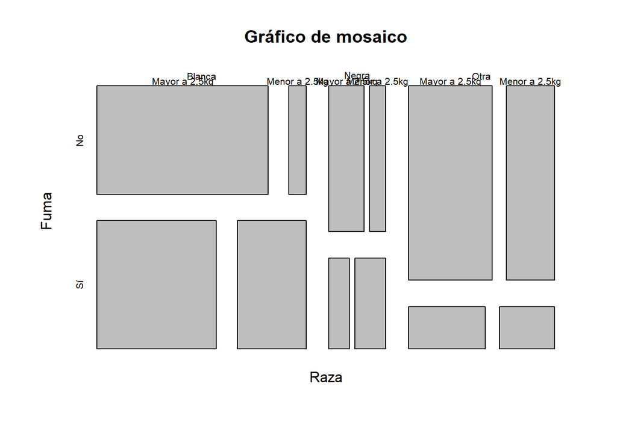

```r
plot(rfxpeso, main = "Gráfico de mosaico")
```